# GenoPred Report

[figure not shown]

Sample Report for ‘opensnp’ dataset

Polygenic scoring & QC summary

## Input processing

This section documents how input data were processed, including quality control steps and harmonisation against the reference panel.

### Target data

**Uploaded target data:**

- 921 individuals.
- vcf format.
- Build GRCh37.
- 7022431 variants.

**Reference data:**

- 3313 individuals.
- 26826073 variants.
- 0 ambiguous variants.

**After harmonisation:**

- Target data contains 5020937 of 26826073 reference variants (18.7%).

### GWAS sumstats

[output not shown]

**Log files:**

#### yengo_eur

```
---------------
 Parameter  Value
 sumstats   /users/k1806347/oliverpainfel/Data/GWAS_sumstats/opensnp_test/yengo_2022_height_eur.txt
 ref_chr    resources/data/ref_dense/ref.chr
 population EUR
 sampling   <NA>
 n          NaN
 info       0.9
 maf        0.01
 maf_diff   0.2
 output     /users/k1806347/oliverpainfel/Data/OpenSNP/GenoPred/dense_test/reference/gwas_sumstat/yengo_eur/yengo_eur-cleaned
 test       NA
 help       FALSE
---------------
Analysis started at 2025-09-24 17:08:10
Reading in sumstats.
GWAS contains 1372608 variants.
---------------
 Original                Interpreted Keep Reason Description
 chromosome              CHR         TRUE NA     Chromosome number
 base_pair_location      BP          TRUE NA     Base pair position
 effect_allele           A1          TRUE NA     Allele 1 (effect allele)
 other_allele            A2          TRUE NA     Allele 2
 beta                    BETA        TRUE NA     BETA effect size
 standard_error          SE          TRUE NA     Standard error of log(OR) or BETA
 effect_allele_frequency FREQ        TRUE NA     Allele frequency
 p_value                 P           TRUE NA     P-value of association
 variant_id              SNP         TRUE NA     RSID for variant
 n                       N           TRUE NA     Total sample size
---------------
After removal of variants that are not SNPs, 1372608 variants remain.
GWAS contains 106671 ambiguous variants.
Merging sumstats with reference using CHR, BP, A1, and A2
GRCh36 match: 0.34% (Target), 0.02% (Ref)
GRCh37 match: 92.52% (Target), 4.99% (Ref)
GRCh38 match: 0.35% (Target), 0.02% (Ref)
After matching variants to the reference, 1256890 variants remain.
1 non-ambiguous variants were flipped to match reference.
INFO column is not present.
After removal of SNPs with reported MAF < 0.01, 1083927 variants remain.
After removal of SNPs with reference MAF < 0.01, 1081034 variants remain.
After removal of SNPs with absolute MAF difference of < 0.2, 1080891 variants remain.
After removal of SNPs with out-of-bound P values, 1080524 variants remain.
After removal of SNPs with duplicate IDs, 1080524 variants remain.
After removal of SNPs with N > 1940643.68119456 or < 1242680.31880544, 1037687 variants remain.
Genomic control was not detected.
After removal of SNPs with SE == 0, 1037687 variants remain.
Analysis finished at 2025-09-24 17:09:37
Analysis duration was 1.46mins
```

#### loh_eur.txt

```
---------------
 Parameter  Value
 sumstats   /users/k1806347/oliverpainfel/Data/GWAS_sumstats/opensnp_test/loh_2018_height_eur.txt
 ref_chr    resources/data/ref_dense/ref.chr
 population EUR
 sampling   <NA>
 n          NaN
 info       0.9
 maf        0.01
 maf_diff   0.2
 output     /users/k1806347/oliverpainfel/Data/OpenSNP/GenoPred/dense_test/reference/gwas_sumstat/loh_eur.txt/loh_eur.txt-cleaned
 test       NA
 help       FALSE
---------------
Analysis started at 2025-09-24 17:07:00
Reading in sumstats.
GWAS contains 12007535 variants.
---------------
 Original                Interpreted Keep  Reason     Description
 variant_id              SNP         TRUE  NA         RSID for variant
 chromosome              CHR         TRUE  NA         Chromosome number
 base_pair_location      BP          TRUE  NA         Base pair position
 effect_allele           A1          TRUE  NA         Allele 1 (effect allele)
 other_allele            A2          TRUE  NA         Allele 2
 REF                     A1          FALSE Duplicated Allele 1 (effect allele)
 effect_allele_frequency FREQ        TRUE  NA         Allele frequency
 beta                    BETA        TRUE  NA         BETA effect size
 standard_error          SE          TRUE  NA         Standard error of log(OR) or BETA
 p_value                 P           TRUE  NA         P-value of association
 n                       N           TRUE  NA         Total sample size
 INFO                    INFO        TRUE  NA         Imputation quality
---------------
After removal of variants that are not SNPs, 12007535 variants remain.
GWAS contains 1805396 ambiguous variants.
Merging sumstats with reference using CHR, BP, A1, and A2
GRCh36 match: 0.33% (Target), 0.14% (Ref)
GRCh37 match: 72.85% (Target), 32.25% (Ref)
GRCh38 match: 0.34% (Target), 0.15% (Ref)
After matching variants to the reference, 8624727 variants remain.
No variants were flipped, indicating GWAS and reference are consistently on the same strand.
After removal of SNPs with INFO < 0.9, 7389902 variants remain.
After removal of SNPs with reported MAF < 0.01, 6265921 variants remain.
After removal of SNPs with reference MAF < 0.01, 6128061 variants remain.
After removal of SNPs with absolute MAF difference of < 0.2, 6127301 variants remain.
After removal of SNPs with out-of-bound P values, 6127173 variants remain.
After removal of SNPs with duplicate IDs, 6127173 variants remain.
N column is not present or invariant.
Genomic control was not detected.
After removal of SNPs with SE == 0, 6127173 variants remain.
Analysis finished at 2025-09-24 17:10:34
Analysis duration was 3.57mins
```

#### verma_eur

```
---------------
 Parameter  Value
 sumstats   /users/k1806347/oliverpainfel/Data/GWAS_sumstats/opensnp_test/verma_2024_height_eur.txt
 ref_chr    resources/data/ref_dense/ref.chr
 population EUR
 sampling   <NA>
 n          NaN
 info       0.9
 maf        0.01
 maf_diff   0.2
 output     /users/k1806347/oliverpainfel/Data/OpenSNP/GenoPred/dense_test/reference/gwas_sumstat/verma_eur/verma_eur-cleaned
 test       NA
 help       FALSE
---------------
Analysis started at 2025-09-24 17:07:00
Reading in sumstats.
GWAS contains 19718047 variants.
---------------
 Original                Interpreted Keep  Reason         Description
 chromosome              CHR         TRUE  NA             Chromosome number
 base_pair_location      BP          TRUE  NA             Base pair position
 effect_allele           A1          TRUE  NA             Allele 1 (effect allele)
 other_allele            A2          TRUE  NA             Allele 2
 beta                    BETA        TRUE  NA             BETA effect size
 standard_error          SE          TRUE  NA             Standard error of log(OR) or BETA
 effect_allele_frequency FREQ        TRUE  NA             Allele frequency
 p_value                 P           TRUE  NA             P-value of association
 rsid                    SNP         TRUE  NA             RSID for variant
 alt                     A2          FALSE Duplicated     Allele 2
 n                       N           TRUE  NA             Total sample size
 r2                      NA          FALSE Not recognised <NA>
 q_pval                  NA          FALSE Duplicated     <NA>
 i2                      NA          FALSE Duplicated     <NA>
 direction               NA          FALSE Duplicated     <NA>
---------------
After removal of variants that are not SNPs, 19718047 variants remain.
GWAS contains 2825014 ambiguous variants.
Merging sumstats with reference using CHR, BP, A1, and A2
GRCh36 match: 0.3% (Target), 0.21% (Ref)
GRCh37 match: 0.3% (Target), 0.21% (Ref)
GRCh38 match: 66.71% (Target), 46.82% (Ref)
After matching variants to the reference, 13000534 variants remain.
140 non-ambiguous variants were flipped to match reference.
INFO column is not present.
After removal of SNPs with reported MAF < 0.01, 6989849 variants remain.
After removal of SNPs with reference MAF < 0.01, 6800349 variants remain.
After removal of SNPs with absolute MAF difference of < 0.2, 6791098 variants remain.
After removal of SNPs with out-of-bound P values, 6789729 variants remain.
After removal of SNPs with duplicate IDs, 6786575 variants remain.
N column is not present or invariant.
Genomic control was not detected.
After removal of SNPs with SE == 0, 6786575 variants remain.
Analysis finished at 2025-09-24 17:11:14
Analysis duration was 4.23mins
```

### External score files

| Name | Label | NSNP (original) | NSNP (non-zero) | NSNP (final) | Sufficient overlap |
| --- | --- | --- | --- | --- | --- |
| PGS002804 | Yengo 2022 Height EUR PGSC | 1097307 | 1096737 | 1010389 | True |
| PGS002972 | ExPRSweb Height raw DBSLMM | 10297262 | 10296980 | 7734608 | False |
| PGS004781 | PRSmixPlus Height EUR | 3215093 | 3215093 | 2203258 | False |
| PGS004996 | Gunn 2024 Height ldpred EUR | 1285709 | 1116665 | 1115517 | True |

**Note.** The `Sufficient overlap` column indicates whether a sufficient proportion (80%) of variants within the score file were present in the reference data.

**Log files:**

#### PGS002804

```
---------------
 Parameter     Value
 ref_plink_chr resources/data/ref_dense/ref.chr
 plink2        plink2
 output        /users/k1806347/oliverpainfel/Data/OpenSNP/GenoPred/dense_test/reference/pgs_score_files/external/PGS002804/ref-PGS002804
 score         /users/k1806347/oliverpainfel/Data/OpenSNP/GenoPred/dense_test/reference/pgs_score_files/raw_external/PGS002804/PGS002804_hmPOS_GRCh37.txt.gz
 min_overlap   0.8
 test          NA
 help          FALSE
 output_dir    /users/k1806347/oliverpainfel/Data/OpenSNP/GenoPred/dense_test/reference/pgs_score_files/external/PGS002804/
---------------
Analysis started at 2025-09-24 17:08:11
Original score file contains 1099005 variants.
PGSC harmonisation data present.
Score file contains 1097307 variants after removing duplicates.
Score file contains 1096737 variants after removing variant with effect size of zero.
Score file contains 82557 ambiguous variants.
Merging sumstats with reference using CHR, BP, A1, and A2
After matching variants to the reference, 1010389 variants remain.
No variants were flipped, indicating score file and reference are consistently on the same strand.
Analysis finished at 2025-09-24 17:12:21
Analysis duration was 4.16 mins
```

#### PGS002972

```
---------------
 Parameter     Value
 ref_plink_chr resources/data/ref_dense/ref.chr
 plink2        plink2
 output        /users/k1806347/oliverpainfel/Data/OpenSNP/GenoPred/dense_test/reference/pgs_score_files/external/PGS002972/ref-PGS002972
 score         /users/k1806347/oliverpainfel/Data/OpenSNP/GenoPred/dense_test/reference/pgs_score_files/raw_external/PGS002972/PGS002972_hmPOS_GRCh37.txt.gz
 min_overlap   0.8
 test          NA
 help          FALSE
 output_dir    /users/k1806347/oliverpainfel/Data/OpenSNP/GenoPred/dense_test/reference/pgs_score_files/external/PGS002972/
---------------
Analysis started at 2025-09-24 17:08:11
Original score file contains 10297262 variants.
PGSC harmonisation data present.
Score file contains 10297262 variants after removing duplicates.
Score file contains 10296980 variants after removing variant with effect size of zero.
Score file contains 1547165 ambiguous variants.
Merging sumstats with reference using CHR, BP, A1, and A2
After matching variants to the reference, 7734608 variants remain.
No variants were flipped, indicating score file and reference are consistently on the same strand.
<80% of non-zero variants in score file are present in the reference (7734608 out of 10296980)
Skipping
Analysis finished at 2025-09-24 17:10:58
Analysis duration was 2.79 mins
```

#### PGS004781

```
---------------
 Parameter     Value
 ref_plink_chr resources/data/ref_dense/ref.chr
 plink2        plink2
 output        /users/k1806347/oliverpainfel/Data/OpenSNP/GenoPred/dense_test/reference/pgs_score_files/external/PGS004781/ref-PGS004781
 score         /users/k1806347/oliverpainfel/Data/OpenSNP/GenoPred/dense_test/reference/pgs_score_files/raw_external/PGS004781/PGS004781_hmPOS_GRCh37.txt.gz
 min_overlap   0.8
 test          NA
 help          FALSE
 output_dir    /users/k1806347/oliverpainfel/Data/OpenSNP/GenoPred/dense_test/reference/pgs_score_files/external/PGS004781/
---------------
Analysis started at 2025-09-24 17:08:11
Original score file contains 3220389 variants.
PGSC harmonisation data present.
Score file contains 3215093 variants after removing duplicates.
Score file contains 3215093 variants after removing variant with effect size of zero.
Score file contains 351453 ambiguous variants.
Merging sumstats with reference using CHR, BP, A1, and A2
After matching variants to the reference, 2203258 variants remain.
6 non-ambiguous variants were flipped to match reference.
WARNING: ambiguous variants are present, but non-ambiguous variants required some flipping, indicating score file and reference data are not consistently on the same strand.
<80% of non-zero variants in score file are present in the reference (2203258 out of 3215093)
Skipping
Analysis finished at 2025-09-24 17:09:46
Analysis duration was 1.58 mins
```

#### PGS004996

```
---------------
 Parameter     Value
 ref_plink_chr resources/data/ref_dense/ref.chr
 plink2        plink2
 output        /users/k1806347/oliverpainfel/Data/OpenSNP/GenoPred/dense_test/reference/pgs_score_files/external/PGS004996/ref-PGS004996
 score         /users/k1806347/oliverpainfel/Data/OpenSNP/GenoPred/dense_test/reference/pgs_score_files/raw_external/PGS004996/PGS004996_hmPOS_GRCh37.txt.gz
 min_overlap   0.8
 test          NA
 help          FALSE
 output_dir    /users/k1806347/oliverpainfel/Data/OpenSNP/GenoPred/dense_test/reference/pgs_score_files/external/PGS004996/
---------------
Analysis started at 2025-09-24 17:08:11
Original score file contains 1286612 variants.
PGSC harmonisation data present.
Score file contains 1285709 variants after removing duplicates.
Score file contains 1116665 variants after removing variant with effect size of zero.
Score file contains 0 ambiguous variants.
Merging sumstats with reference using CHR, BP, A1, and A2
After matching variants to the reference, 1115517 variants remain.
2 non-ambiguous variants were flipped to match reference.
Analysis finished at 2025-09-24 17:12:32
Analysis duration was 4.35 mins
```

## Ancestry inference

This section documents the target sample ancestry inference results.

- 837 out of 921 target individuals in the sample, were assigned to a reference population with a probability >95%.
- The number of individuals assigned to each population were:

| Population | N |
| --- | --- |
| AFR | 18 |
| AMR | 17 |
| CSA | 16 |
| EAS | 17 |
| EUR | 769 |
| MID | 0 |
| Unassigned | 84 |

**Target Principal Component Scores Compared to Reference Populations.**

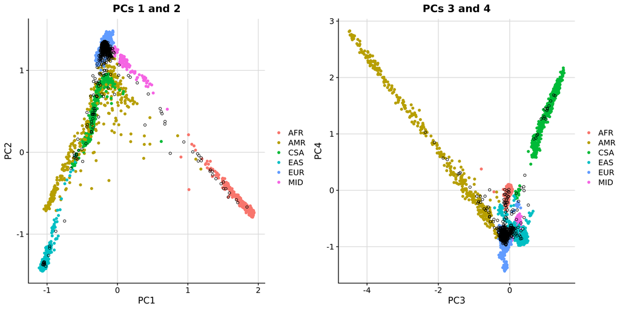

**Note.** Black circles indicate target sample individuals.

## Polygenic Scores

This section summarises the polygenic scores (PGS), showing the correlation between PGS, the number of PGS variants present in the target sample, and the distribution of PGS in the target sample.

### PGS correlation

This section shows the correlation between PGS in the reference sample. This is intended as a sanity check that the PGS correlations are in the expected direction, thereby confirming the GWAS alleles are being interpreted correctly.

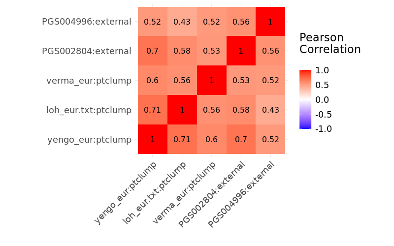

**Note.** Plot shows correlation between pseudovalidated PGS in TRANS population.

### PGS coverage

This section summarises the polygenic score files, including both GWAS-derived and external scores. It reports the number of SNPs per score, the proportion present in the target sample, and the relative R² accounting for missing variants. These metrics provide a check on score completeness, transferability, and the expected predictive utility in the target data.

| ID | Method | N SNP (original) | Overlap with target | Relative R2 in target (EUR) | Overlap with EUR LD reference |
| --- | --- | --- | --- | --- | --- |
| PGS002804 | external | 1096737 | 85.1% | 93.3% | 91.4% |
| PGS004996 | external | 1116665 | 91.8% | 92.6% | 97.5% |
| loh_eur.txt | ptclump | 315175 | 33.7% | 43.6% | 95.6% |
| verma_eur | ptclump | 373595 | 31.8% | 36.3% | 83.2% |
| yengo_eur | ptclump | 111059 | 78.9% | 86.8% | 98% |

**Note.** Table only considers variants with non-zero effect size in the pseudovalidated PGS for each method-gwas/score pair. N SNP (original) = Number of variants in score file; Missingness in target = Mean missingness of variants in target sample; Relative R2 = Estimated relative R2 of PGS in target sample given missing variants; N SNP (in LD reference)= Number of variants present in LD reference data used to estimate relative R2.

### PGS Distribution

This section shows the distribution of PGS in the target sample. PGS are shown scaled according to each ancestry-match reference population. TRANS includes PGS across all populations after continuous adjustment for ancestry.

#### ptclump

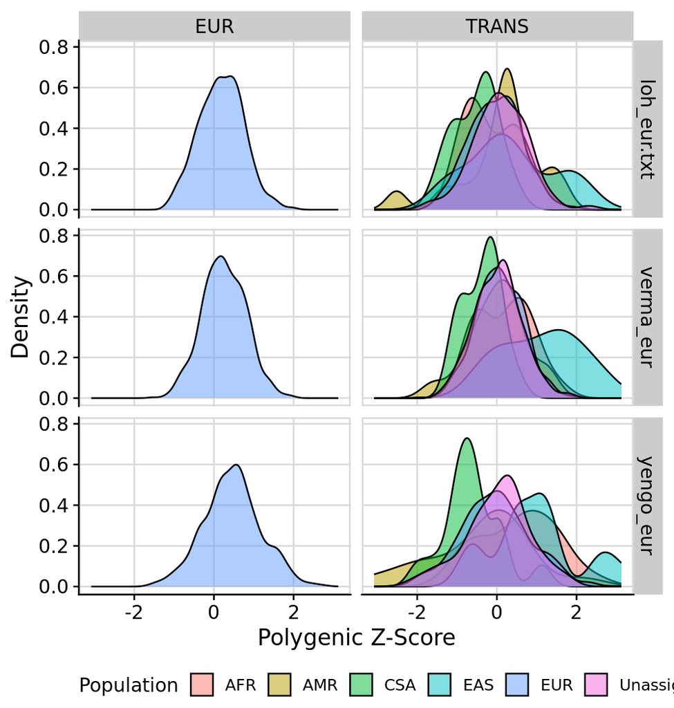

**Note.** Plot shows distribution of pseudovalidated PGS.

#### external

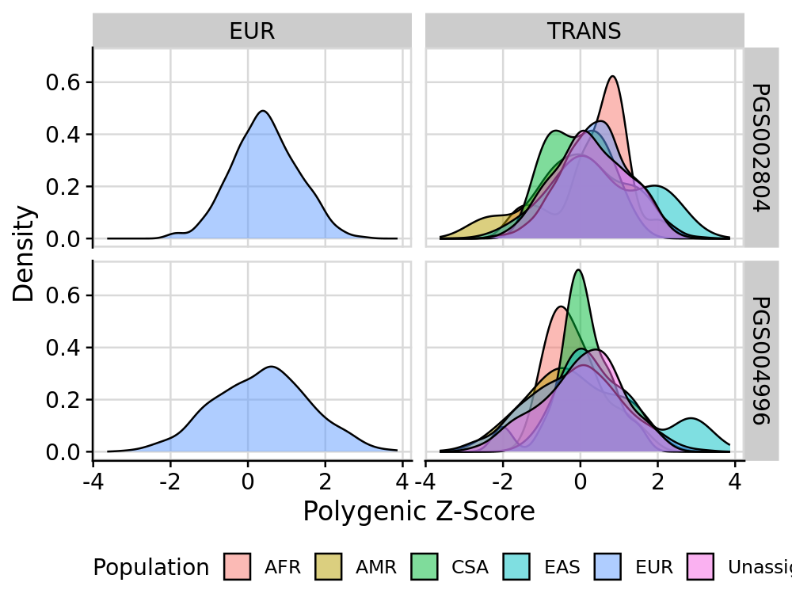

**Note.** Plot shows distribution of pseudovalidated PGS.

## Configuration

### target_list

| name | path | type | indiv_report |
| --- | --- | --- | --- |
| opensnp | /users/k1806347/oliverpainfel/Data/OpenSNP/processed/geno/opensnp_merged | vcf | F |

### gwas_list

| name | path | population | n | sampling | prevalence | mean | sd | label |
| --- | --- | --- | --- | --- | --- | --- | --- | --- |
| yengo_eur | /users/k1806347/oliverpainfel/Data/GWAS_sumstats/opensnp_test/yengo_2022_height_eur.txt | EUR | NA | NA | NA | NA | NA | Yengo 2022 Height EUR |
| loh_eur.txt | /users/k1806347/oliverpainfel/Data/GWAS_sumstats/opensnp_test/loh_2018_height_eur.txt | EUR | NA | NA | NA | NA | NA | Loh 2018 Height EUR |
| verma_eur | /users/k1806347/oliverpainfel/Data/GWAS_sumstats/opensnp_test/verma_2024_height_eur.txt | EUR | NA | NA | NA | NA | NA | Verma 2024 Height EUR |

### score_list

| name | path | label |
| --- | --- | --- |
| PGS002804 | NA | Yengo 2022 Height EUR PGSC |
| PGS002972 | NA | ExPRSweb Height raw DBSLMM |
| PGS004781 | NA | PRSmixPlus Height EUR |
| PGS004996 | NA | Gunn 2024 Height ldpred EUR |

### configfile

| Parameter | Value |
| --- | --- |
| outdir | /users/k1806347/oliverpainfel/Data/OpenSNP/GenoPred/dense_test |
| dense_reference | T |
| config_file | misc/opensnp/config_dense.yaml |
| gwas_list | misc/opensnp/gwas_list_dense_test.txt |
| score_list | misc/opensnp/score_list_dense_test.txt |
| target_list | misc/opensnp/target_list.txt |
| pgs_scaling | ['discrete', 'continuous'] |
| target_populations | ['EUR'] |
| pgs_methods | ['ptclump'] |
| resdir | NA |

[output cut: 29 more lines]

### Version

This report was created using GenoPred (v2.2.12-97-g8402ebb).